# 2-Simple Time Series Analysis

Author: Foad Yousef

Institute: University of California Los Angeles

Last Modifed: 3/11/2017

## R setup, data extraction, and visualization

Processing raw Landsat imagery is fast and straightforward with R. R is a statistical analysis software with growing capabilities. The R’s success is partially related to growing number of tools and packages that are available to users. We will be working with many of them. You will have the chance to learn how to download, install, and work with this packages.

**1.** Start R. Note: You can install R-studio in order to make R even more user friendly.

You can download R-studio at: https://www.rstudio.com/products/rstudio/download/ Find the proper version at the bottom of the page, download, and install it!

**2.** Open a R-script window by clicking on File>New File> R-script.

**3.** The new window is where you would insert you R Script.

**4.** As a starter, we would like to install a few packages in order to work with Landsat Images.

- Use `install.packge("NAME OF THE PACKGE")` to install any package. However, since `bfastSpatial` package is still underdevelopment, you would need to install it directly from “github”. Install `devtools` first. Then, use `install_github` to install `bfastSpatial`. The rest is very typical:

```r
install.packages('devtools')
install_github('loicdtx/bfastSpatial')
install.packages("rgdal")
install.packages("raster")
```

- Now load the installed packages:

```r
require('devtools')
require('bfastSpatial')
require("rgdal")
require("raster")
require("tools")
```

Note: R is case sensitive; Uppercase and lowercase words and commands an functions are different from one another.

**5.** Define the input and output directory for both the data and the shapefile:

**Warning:** Please check the below directories and change them to match data directories in your computer.

```r
indir <- "D:/UCLA/SAMPLE_DATA/2-simple_vis/"
outdir <- "D:/UCLA/SAMPLE_DATA/2-simple_vis/out"
dir.create(outdir, showWarning=FALSE)
crop_file<- paste0("D:/UCLA/SAMPLE_DATA/shpfile/CO5.shp")
```

**6.** Locate the tar files to be processed:

```r
mylist <- list.files(indir, full.names=TRUE, pattern="*.gz")
```

**7.** Read the shapefile to crop the data into the desired extent. We call it Crop_obj (Crop Object) and it is the extent for the CO5 (Colorado 5) station.

```r
crop_name <- file_path_sans_ext(basename(crop_file))
crop_obj <- readOGR(dsn=crop_file, crop_name, verbose = FALSE)
```

**8.** Generate (or extract, depending on whether the layer is already in the archive or not) NDVI for the first archived file. Notice that we are using the above shapefile to crop the Landsat image. We will only work with the area inside the crop object.

Also notice that a mask (mask=) had to be selected; in that case ‘fmask’, which is one of the layers of the Landsat archive file delivered by USGS/ESPA. For details about that mask and know which values to keep (keep=), you can visit this [page](https://github.com/usgs-eros/espa-cloud-masking), or for general information on the layers provided in the archive, see the [product guide](https://landsat.usgs.gov/sites/default/files/documents/espa_odi_userguide.pdf).

Masking and cropping are optional but highly recommended if you intend to perform subsequent time-series analysis with the layers produced.

The extension of the output is by default .grd. This is the native format of the raster package. This format has many advantages over more common GeoTiff or ENVI formats.

```r
processLandsat(x=mylist[1], vi='ndvi', outdir=outdir, srdir=outdir, delete=TRUE,
               mask='fmask', keep=0, e=extent(crop_obj), overwrite=TRUE)
```

**9.** The results of the above function has produced a nice sections of NDVI imagery for our study site. Lets plot that:

```r
list <- list.files(outdir, pattern=glob2rx('*.grd'), full.names=TRUE)
plot(r <- mask(raster(list[1]), crop_obj))
```

[output not shown]

#### Activity 1: Process the second file in your input directory and save the output in the “out” folder.

## Visualization of Multiple Landsat Scenes

Now we would like to attempt to visualize both layers and processed to perform a time series analysis.

**1.** Make a list of both of you output files.

```r
list <- list.files(outdir, pattern=glob2rx('*.grd'), full.names=TRUE)
```

**2.** Print the filenames and their location. This is just to check how many files do we have in the system.

```r
print(list)
```

```
## [1] "D:/UCLA/SAMPLE_DATA/2-simple_vis/out/ndvi.LT50330322011184.grd"
## [2] "D:/UCLA/SAMPLE_DATA/2-simple_vis/out/ndvi.LT50330322011200.grd"
```

You can also simply type the `list` name in you console and print the values.

```r
list
```

```
## [1] "D:/UCLA/SAMPLE_DATA/2-simple_vis/out/ndvi.LT50330322011184.grd"
## [2] "D:/UCLA/SAMPLE_DATA/2-simple_vis/out/ndvi.LT50330322011200.grd"
```

#### Activity 2: How many files do you see listed in your out directory? Can you tell their dates by looking at the filename?

### Creating a multi-temporal raster object

**3.** Once the vegetation index layers have been produced for several dates, they can be stacked, in order to create a multilayer raster object, with time dimension written in the file as well. The function to perform this operation on Landsat data is the `timeStack` function. By simply providing a list of file names or a directory containing the files, the function will create a multilayer object and directly parse through the file names to extract temporal information from them and write that information to the object created.

Create a new sub-directory to store the raster stack

```r
outdir2 <- paste0(outdir,"/", "stack_new")
dir.create(outdir2, showWarnings=FALSE)
```

**4.** Generate a file name for the output stack

```r
stackName <- file.path(outdir2, 'CO5_Stack.grd')
```

**5.** Stack the layers.

```r
s <- timeStack(x=list, filename=stackName, datatype='INT2S', overwrite=TRUE)
```

**6.** Visualize both layers.

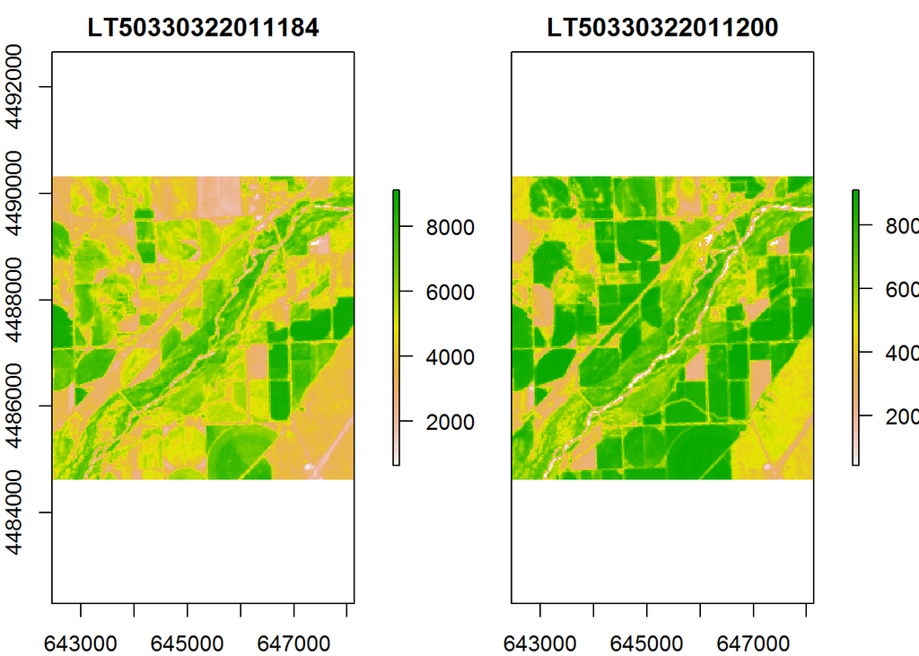

```r
plot(s)
```

**7.** Processed to mask out the unwanted regions using the `crop_obj`.

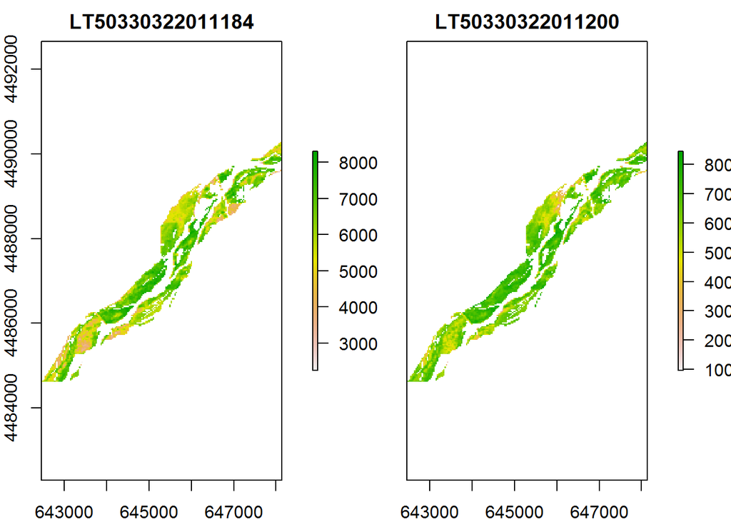

```r
plot(mask(s, crop_obj))
```

About the example above:

- For this function to work, tt is absolutely necessary that the input layers have the same extent. Two Landsat scenes belonging to the same path/row, but acquired at different times often have slightly different extents. We therefore recommend to always use an extent object in `processLandsat`, even when working with full scenes.
- Time information is automatically extracted from the layer names (using `getSceneInfo`) and written to the z dimension of the stack.
- We chose to write the output to the .grd format, which allows the time information to be stored as well as the original layer names.
- The `x=` argument can also simply be the directory containing the layers; in which case we recommend using `pattern=` as well in order to ensure that only the desired files are included.